# Stability Launch Notebook

Open-source Software, open-standards, and services for interactive computing across dozens of programming languages.

I will be using this notebook with Python to present our data in real-time analysis

Utilizing the Python programming language to analyze our stability launch data Python contains powerful analysis tools and packages that are limited in Excel

- Data cleaning
- Transformation
- Numerical Simulation
- Statistical Modeling
- Diverse Data Visualization Methods (will be using mostly Seaborn)
- Machine learning models and algorithms

# Product Flow for Stability Launch Analysis Machine (SLAM)

[figure not shown]

# Questions to be answered

- What am I doing when I'm analyzing data?
- What is my process and how do I visualize data?
- How does delays, multiple orientations, and linked samples affect our launches/workload?
- What are the rates of ambient, cold, and frozen launches.
- How does this relate to our excel tool?

```python
#Import necessary packages and initiate pandas dataframe for stability launch data.
import numpy as np
import pandas as pd
import matplotlib.pyplot as plt
import itertools as itt
import xlrd
%matplotlib inline

#Read the excel file into a dataframe
stab_data = pd.ExcelFile('Excel Data.xlsx')

df = stab_data.parse('Sheet1')
df.head()
```

|  | Container type | # of samples | # of reserves | # of containers | # of labels | Pre-launch condition? Ambient/5C/frozen | Multiple Orientations? Y/N | Linked samples? Y/N | Unexpected delays (late change, etc.)? Y/N | Review info (hrs) | Log-in (hrs) | Label (hrs) | Verify (hrs) | Launch (hrs) |
| --- | --- | --- | --- | --- | --- | --- | --- | --- | --- | --- | --- | --- | --- | --- |
| 0 | MDI cannisters and pouches | 70 | 17 | 5165 | 10330.0 | Ambient | Y | Y | Y | 2.00 | 8.00 | 100.0 | 80.0 | 2.00 |
| 1 | glass syringes | 48 | 9 | 7110 | 7110.0 | 5C | N | N | Y | 0.25 | 1.50 | 36.0 | 32.0 | 0.75 |
| 2 | Foil pouch | 72 | 17 | 5135 | 5135.0 | Ambient | Y | Y | Y | 2.00 | 4.00 | NaN | NaN | NaN |
| 3 | packets | 108 | 16 | 5060 | 5060.0 | Ambient | N | N | Y | 0.75 | 2.75 | 18.0 | 18.0 | 1.00 |
| 4 | Glass Vial | 60 | 10 | 4086 | 4086.0 | 5C | Y | N | Y | 0.25 | 1.50 | 19.0 | 22.0 | 1.50 |

# Why do we want to use pandas over excel?

Many companies use python language with Pandas dataframe to conduct backend data collection and calculations Also used by the scientific, financial, educational, engineering fields for data analysis.

[figure not shown]

## Reproducibility

- Pandas can read and convert to many types of files (csv, txt, json, and even excel files).
- Can be used to read not only stability launch data but other data as well.

## Scalability

- Pandas dataframe is one of the fastest data analysis tools because it also utilizes dask.
- Can read as much data as the memory (RAM) on a computer/laptop permits. Versus excel that only reads ~1 million rows.
- Dataframe structure allows for quick and easy analysis of data through other languages and platforms.

## Educational and Presentation Purposes

- Anyone can generate graphs, reports, and spreadsheets/calculators with a click of a button for quick reports.
- A quick way to summarize our stability launch process which in turn will:
  - Help educate the lab about our process so they know how they can better fit into our process.
  - Help educate new sample management employees about our stability launch process.
  - Gives us the ability to look into and question our processes to find gaps and further improve our process.
  - Can give us the ability to look into relogs, chamber reconiliation, and analysis of other processes.

## Coolness factor

- We get to use machine learning algorithms that are utilized by leading tech companies of the world.
- All of the data analysis will be automated
- Generate diverse sets of graphical data.

# Before we begin we have to clean up our data.

## Data Wrangling & Clean Up Process

- Clean up the data and make it workable in the dataframe
  - Fix input Errors
  - Fill in missing data (utilizing means, medians, and modes)
  - Remove unworkable data

```python
#Rename every column for programming/dataframe purposes
df = df.rename(columns = {
    'Contract/ project #s': 'contract_project',
    'Container type': 'container_type',
    '# of samples' : 'sample_number',
    '# of reserves' : 'reserve_number',
    '# of labels' : 'label_number',
    '# of containers': 'container_number',
    'Pre-launch condition? Ambient/5C/frozen': 'prel_condition',
    'Multiple Orientations? Y/N': 'multi_orient',
    'Linked samples? Y/N': 'linked',
    'Unexpected delays (late change, etc.)? Y/N': 'delays',
    'Review info (hrs)': 'review_time',
    'Log-in (hrs)': 'login_time',
    'Label (hrs)': 'label_time',
    'Verify (hrs)': 'verify_time',
    'Launch (hrs)': 'launch_time',
    'Owner of launch:' : 'launch_owner'})
```

```python
#Fill in with blank cells with median, mean, or mode
df['container_number'] = df['container_number'].fillna(df['container_number'].mean())
#df['label_number'] = df['label_number'].fillna(df['label_number'].mean())
df['review_time'] = df['review_time'].fillna(df['review_time'].median())
df['login_time'] = df['login_time'].fillna(df['login_time'].mean())
df['launch_time'] = df['launch_time'].fillna(df['launch_time'].median())
#df['launch_owner'] = df['launch_owner'].fillna('Unknown')

#Drop the missing values from label and verify time also aliquots.
df.dropna(inplace=True)

#Fill in unknown status of columns
df['multi_orient'] = df['multi_orient'].fillna('N')
df['linked'] = df['linked'].fillna('N')
df['delays'] = df['delays'].fillna('N')
df['container_type'] = df['container_type'].fillna('Unknown')

df.head()
```

|  | container_type | sample_number | reserve_number | container_number | label_number | prel_condition | multi_orient | linked | delays | review_time | login_time | label_time | verify_time | launch_time |
| --- | --- | --- | --- | --- | --- | --- | --- | --- | --- | --- | --- | --- | --- | --- |
| 0 | MDI cannisters and pouches | 70 | 17 | 5165 | 10330.0 | Ambient | Y | Y | Y | 2.00 | 8.00 | 100.0 | 80.0 | 2.00 |
| 1 | glass syringes | 48 | 9 | 7110 | 7110.0 | 5C | N | N | Y | 0.25 | 1.50 | 36.0 | 32.0 | 0.75 |
| 3 | packets | 108 | 16 | 5060 | 5060.0 | Ambient | N | N | Y | 0.75 | 2.75 | 18.0 | 18.0 | 1.00 |
| 4 | Glass Vial | 60 | 10 | 4086 | 4086.0 | 5C | Y | N | Y | 0.25 | 1.50 | 19.0 | 22.0 | 1.50 |
| 5 | Blister packs | 141 | 15 | 3249 | 3249.0 | Ambient | N | N | Y | 0.25 | 3.00 | 10.0 | 8.0 | 0.50 |

```python
#Create columns for total time (sum of review, login, label, verify, and launch time)
total_time_df = df[['review_time','login_time','label_time','verify_time','launch_time']]
total_sample_reserve = df[['sample_number','reserve_number']]


df['total_time']= total_time_df.sum(axis=1)
df['total_SR'] = total_sample_reserve.sum(axis=1)
df
```

|  | container_type | sample_number | reserve_number | container_number | label_number | prel_condition | multi_orient | linked | delays | review_time | login_time | label_time | verify_time | launch_time | total_time | total_SR |
| --- | --- | --- | --- | --- | --- | --- | --- | --- | --- | --- | --- | --- | --- | --- | --- | --- |
| 0 | MDI cannisters and pouches | 70 | 17 | 5165 | 10330.0 | Ambient | Y | Y | Y | 2.00 | 8.00 | 100.00 | 80.00 | 2.00 | 192.00 | 87 |
| 1 | glass syringes | 48 | 9 | 7110 | 7110.0 | 5C | N | N | Y | 0.25 | 1.50 | 36.00 | 32.00 | 0.75 | 70.50 | 57 |
| 3 | packets | 108 | 16 | 5060 | 5060.0 | Ambient | N | N | Y | 0.75 | 2.75 | 18.00 | 18.00 | 1.00 | 40.50 | 124 |
| 4 | Glass Vial | 60 | 10 | 4086 | 4086.0 | 5C | Y | N | Y | 0.25 | 1.50 | 19.00 | 22.00 | 1.50 | 44.25 | 70 |
| 5 | Blister packs | 141 | 15 | 3249 | 3249.0 | Ambient | N | N | Y | 0.25 | 3.00 | 10.00 | 8.00 | 0.50 | 21.75 | 156 |
| 6 | Blister packs | 141 | 15 | 3249 | 3249.0 | Ambient | N | N | N | 0.25 | 2.00 | 11.50 | 12.50 | 0.75 | 27.00 | 156 |
| 7 | glass vials | 32 | 5 | 3000 | 3000.0 | Frozen | N | N | Y | 0.25 | 1.50 | 23.00 | 15.00 | 0.75 | 40.50 | 37 |
| 8 | Unisticks | 87 | 15 | 2400 | 2400.0 | 5C | N | Y | Y | 1.00 | 4.00 | 11.00 | 14.00 | 0.75 | 30.75 | 102 |
| 10 | Epipens | 24 | 3 | 2270 | 2130.0 | Ambient | N | N | Y | 0.25 | 1.00 | 7.00 | 9.25 | 0.25 | 17.75 | 27 |
| 11 | Blister Packs | 56 | 12 | 2049 | 2049.0 | Ambient | N | N | N | 0.25 | 0.50 | 10.00 | 11.75 | 0.50 | 23.00 | 68 |
| 12 | glass vials | 39 | 4 | 1507 | 2012.0 | 5C | Y | Y | N | 2.00 | 4.00 | 12.00 | 16.00 | 1.00 | 35.00 | 43 |
| 13 | Plastic Auto-Injectors | 8 | 1 | 1792 | 1792.0 | Ambient | N | N | N | 0.75 | 1.50 | 8.50 | 9.50 | 0.50 | 20.75 | 9 |
| 14 | glass vials | 39 | 9 | 1640 | 1640.0 | 5C | Y | N | N | 0.25 | 0.75 | 6.00 | 7.50 | 0.50 | 15.00 | 48 |
| 15 | blister strips | 48 | 5 | 1620 | 1620.0 | Ambient | N | N | N | 0.25 | 0.75 | 4.00 | 4.00 | 0.50 | 9.50 | 53 |
| 16 | Devices in a box and vials | 8 | 5 | 930 | 1488.0 | Ambient | Y | N | N | 0.25 | 1.00 | 4.50 | 3.00 | 2.00 | 10.75 | 13 |
| 17 | glass vials | 41 | 8 | 1471 | 1471.0 | 5C | Y | N | N | 0.50 | 1.00 | 4.00 | 6.50 | 0.25 | 12.25 | 49 |
| 18 | Stick Packs | 24 | 8 | 1265 | 1265.0 | Ambient | N | N | Y | 0.75 | 1.50 | 3.25 | 3.50 | 0.50 | 9.50 | 32 |
| 19 | Epipens | 27 | 6 | 1260 | 1260.0 | Ambient | N | N | N | 0.25 | 0.75 | 4.50 | 7.50 | 0.50 | 13.50 | 33 |
| 20 | Syringes | 51 | 9 | 1182 | 1182.0 | 5C | N | N | N | 0.75 | 2.00 | 5.00 | 7.00 | 0.50 | 15.25 | 60 |
| 21 | Glass Vials | 28 | 7 | 1055 | 1055.0 | 5C | Y | N | N | 0.50 | 0.50 | 6.00 | 8.00 | 0.75 | 15.75 | 35 |
| 22 | glass vials | 23 | 4 | 1024 | 1024.0 | 5C | Y | N | Y | 0.25 | 0.75 | 10.00 | 14.00 | 0.50 | 25.50 | 27 |
| 23 | Stick Packs | 25 | 8 | 1012 | 1012.0 | Ambient | N | N | Y | 0.50 | 2.00 | 2.50 | 2.50 | 0.50 | 8.00 | 33 |
| 24 | blister strips | 160 | 30 | 1000 | 1000.0 | 5C | n | n | Y | 0.25 | 1.50 | 5.00 | 5.00 | 0.75 | 12.50 | 190 |
| 25 | Glass Vials | 834 | 103 | 937 | 937.0 | 5C | N | N | Y | 1.00 | 1.00 | 3.00 | 3.00 | 0.50 | 8.50 | 937 |
| 26 | Blister Cards | 45 | 6 | 889 | 889.0 | Ambient | N | N | N | 0.25 | 1.00 | 2.50 | 3.50 | 0.25 | 7.50 | 51 |
| 27 | ampoules | 14 | 2 | 750 | 850.0 | Ambient | N | Y | N | 0.25 | 1.00 | 2.00 | 2.00 | 0.25 | 5.50 | 16 |
| 28 | glass vials | 52 | 12 | 840 | 840.0 | 5C | Y | N | N | 0.25 | 2.50 | 3.50 | 3.00 | 0.50 | 9.75 | 64 |
| 29 | glass vials | 22 | 3 | 834 | 834.0 | 5C | Y | N | Y | 0.75 | 0.75 | 2.50 | 3.00 | 0.50 | 7.50 | 25 |
| 30 | glass syringes | 11 | 2 | 787 | 787.0 | 5C | N | N | N | 0.25 | 0.75 | 2.75 | 4.50 | 0.50 | 8.75 | 13 |
| 31 | Blister in foil pouch | 137 | 18 | 780 | 780.0 | Ambient | N | N | N | 1.00 | 5.50 | 6.50 | 8.00 | 1.00 | 22.00 | 155 |
| ... | ... | ... | ... | ... | ... | ... | ... | ... | ... | ... | ... | ... | ... | ... | ... | ... |
| 103 | Foil pouches | 16 | 4 | 38 | 38.0 | Ambient | N | N | N | 0.25 | 0.50 | 0.50 | 0.50 | 0.25 | 2.00 | 20 |
| 104 | HDPE bottles | 36 | 0 | 36 | 36.0 | Ambient | N | N | Y | 0.25 | 1.50 | 0.50 | 0.50 | 1.00 | 3.75 | 36 |
| 105 | Glass Vials | 1 | 0 | 36 | 36.0 | 5C | N | N | N | 0.25 | 0.25 | 0.50 | 0.50 | 0.25 | 1.75 | 1 |
| 106 | Foil Pouches | 13 | 6 | 34 | 34.0 | Frozen | N | N | Y | 0.50 | 1.50 | 1.00 | 0.50 | 0.25 | 3.75 | 19 |
| 107 | Satorius Celsius-Pak, 30mL Bag | 19 | 3 | 33 | 33.0 | Frozen | N | N | N | 0.25 | 1.00 | 0.50 | 0.75 | 1.00 | 3.50 | 22 |
| 108 | IV Bag | 19 | 3 | 33 | 33.0 | Frozen | N | N | N | 0.25 | 0.25 | 0.25 | 0.50 | 0.25 | 1.50 | 22 |
| 109 | Vial Boxes | 9 | 0 | 16 | 32.0 | Frozen | N | N | N | 0.25 | 0.75 | 0.50 | 0.50 | 1.50 | 3.50 | 9 |
| 110 | 50 mL Hyclone bags | 12 | 2 | 30 | 30.0 | Frozen | N | N | N | 0.25 | 0.50 | 0.25 | 0.25 | 0.25 | 1.50 | 14 |
| 111 | Carton | 4 | 1 | 30 | 30.0 | Ambient | N | N | N | 0.25 | 1.00 | 0.25 | 0.25 | 0.25 | 2.00 | 5 |
| 112 | Blister packs | 4 | 2 | 24 | 24.0 | 5C | N | N | N | 0.25 | 0.50 | 0.25 | 0.25 | 0.25 | 1.50 | 6 |
| 113 | Glass Vials | 1 | 0 | 24 | 24.0 | 5C | N | N | Y | 0.25 | 0.25 | 0.25 | 0.25 | 0.25 | 1.25 | 1 |
| 114 | Glass Vials | 1 | 0 | 24 | 24.0 | 5C | N | N | Y | 0.25 | 0.25 | 0.25 | 0.25 | 0.25 | 1.25 | 1 |
| 115 | glass vials | 1 | 0 | 24 | 24.0 | 5C | N | N | N | 0.25 | 0.25 | 0.25 | 0.25 | 0.25 | 1.25 | 1 |
| 116 | HDPE bottles | 22 | 0 | 22 | 22.0 | 5C | N | N | Y | 0.25 | 1.00 | 0.25 | 0.25 | 0.25 | 2.00 | 22 |
| 117 | Cryo Box | 5 | 0 | 11 | 22.0 | Frozen | N | N | N | 0.25 | 0.50 | 0.50 | 0.50 | 0.25 | 2.00 | 5 |
| 118 | blister strips | 12 | 2 | 21 | 21.0 | Ambient | N | N | N | 0.25 | 0.50 | 0.25 | 0.25 | 0.25 | 1.50 | 14 |
| 119 | blister strips | 11 | 2 | 21 | 21.0 | Ambient | N | N | N | 0.25 | 0.50 | 0.25 | 0.25 | 0.25 | 1.50 | 13 |
| 121 | Drug coated balloons | 1 | 0 | 18 | 18.0 | Ambient | N | N | N | 0.25 | 0.25 | 0.25 | 0.25 | 0.25 | 1.25 | 1 |
| 124 | Vial Boxes | 9 | 0 | 16 | 16.0 | -70 | N | N | N | 0.50 | 1.50 | 0.50 | 0.50 | 0.75 | 3.75 | 9 |
| 126 | Cryo Box | 4 | 0 | 6 | 12.0 | Frozen | N | N | N | 0.25 | 0.50 | 0.50 | 0.50 | 0.25 | 2.00 | 4 |
| 127 | HDPE bottles | 4 | 2 | 8 | 8.0 | 5C | N | N | N | 0.25 | 0.25 | 0.25 | 0.25 | 0.50 | 1.50 | 6 |
| 128 | Shipping boxes | 7 | 0 | 7 | 7.0 | 25/60 | N | N | N | 0.25 | 0.25 | 0.25 | 0.25 | 0.25 | 1.25 | 7 |
| 129 | Glass vials | 4 | 1 | 7 | 7.0 | Frozen | N | N | N | 0.25 | 0.25 | 0.25 | 0.25 | 0.25 | 1.25 | 5 |
| 130 | plastic bottles | 2 | 0 | 6 | 6.0 | Ambient | N | N | N | 0.25 | 0.50 | 0.25 | 0.25 | 0.25 | 1.50 | 2 |
| 131 | plastic vials | 1 | 0 | 3 | 6.0 | Frozen | N | N | N | 0.50 | 0.25 | 0.25 | 0.25 | 0.50 | 1.75 | 1 |
| 133 | plastic bottles | 3 | 0 | 4 | 4.0 | Ambient | N | N | N | 0.25 | 0.50 | 0.25 | 0.25 | 0.50 | 1.75 | 3 |
| 134 | Shipping boxes of balloons | 2 | 0 | 2 | 2.0 | Ambient | N | N | N | 0.25 | 0.25 | 0.25 | 0.25 | 0.25 | 1.25 | 2 |
| 135 | Drug coated balloons | 2 | 0 | 2 | 2.0 | Ambient | N | N | N | 0.25 | 0.25 | 0.25 | 0.25 | 0.25 | 1.25 | 2 |
| 136 | glass vials | 2 | 0 | 2 | 2.0 | Frozen | Y | N | N | 0.25 | 0.25 | 0.25 | 0.25 | 0.50 | 1.50 | 2 |
| 137 | Glass Vials | 12 | 8 | 1512 | 1512.0 | 5C | Y | N | N | 1.25 | 1.50 | 6.00 | 8.50 | 1.00 | 18.25 | 20 |

120 rows ﾗ 16 columns

```python
#Create a replacement dictionary for spelling errors, missing values, and create binary values.

d = {#Replace yes and no with 1s and 0s
     'N': 0,
     'Y': 1,
     'n': 0,
     'y': 1,

     #Prelaunch Conditions normalize to Frozen, Ambient, or 5C
     -70: 'Frozen',
     -80: 'Frozen',
     -20: 'Frozen',
     'frozen': 'Frozen',
     'ambient': 'Ambient',
     '25/60': 'Ambient',

     #Container Types
     'glass vials': 'Glass Vials',
     'foil pouches': 'Foil Pouches',
     'glass vial': 'Glass Vials',
     'foil bags': 'Foil Pouches',
     'Foil pouch': 'Foil Pouches',
     'plastic bottles': 'Plastic Bottles',
     'HDPE bottle': 'HDPE Bottle',
    }

df = df.replace(d)
df.head(10)
```

|  | container_type | sample_number | reserve_number | container_number | label_number | prel_condition | multi_orient | linked | delays | review_time | login_time | label_time | verify_time | launch_time | total_time | total_SR |
| --- | --- | --- | --- | --- | --- | --- | --- | --- | --- | --- | --- | --- | --- | --- | --- | --- |
| 0 | MDI cannisters and pouches | 70 | 17 | 5165 | 10330.0 | Ambient | 1 | 1 | 1 | 2.00 | 8.00 | 100.0 | 80.00 | 2.00 | 192.00 | 87 |
| 1 | glass syringes | 48 | 9 | 7110 | 7110.0 | 5C | 0 | 0 | 1 | 0.25 | 1.50 | 36.0 | 32.00 | 0.75 | 70.50 | 57 |
| 3 | packets | 108 | 16 | 5060 | 5060.0 | Ambient | 0 | 0 | 1 | 0.75 | 2.75 | 18.0 | 18.00 | 1.00 | 40.50 | 124 |
| 4 | Glass Vial | 60 | 10 | 4086 | 4086.0 | 5C | 1 | 0 | 1 | 0.25 | 1.50 | 19.0 | 22.00 | 1.50 | 44.25 | 70 |
| 5 | Blister packs | 141 | 15 | 3249 | 3249.0 | Ambient | 0 | 0 | 1 | 0.25 | 3.00 | 10.0 | 8.00 | 0.50 | 21.75 | 156 |
| 6 | Blister packs | 141 | 15 | 3249 | 3249.0 | Ambient | 0 | 0 | 0 | 0.25 | 2.00 | 11.5 | 12.50 | 0.75 | 27.00 | 156 |
| 7 | Glass Vials | 32 | 5 | 3000 | 3000.0 | Frozen | 0 | 0 | 1 | 0.25 | 1.50 | 23.0 | 15.00 | 0.75 | 40.50 | 37 |
| 8 | Unisticks | 87 | 15 | 2400 | 2400.0 | 5C | 0 | 1 | 1 | 1.00 | 4.00 | 11.0 | 14.00 | 0.75 | 30.75 | 102 |
| 10 | Epipens | 24 | 3 | 2270 | 2130.0 | Ambient | 0 | 0 | 1 | 0.25 | 1.00 | 7.0 | 9.25 | 0.25 | 17.75 | 27 |
| 11 | Blister Packs | 56 | 12 | 2049 | 2049.0 | Ambient | 0 | 0 | 0 | 0.25 | 0.50 | 10.0 | 11.75 | 0.50 | 23.00 | 68 |

# Data Visualization with Seaborn

Seaborn: Python package that interacts nicely with Pandas for data visualization

```python
#import Seaborn conventionally
import seaborn as sns
```

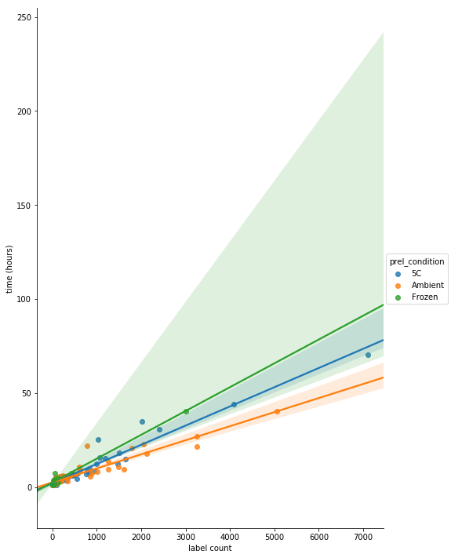

```python
launch_df = df.loc[df['label_number'] < 8000]
launch_plot = sns.pairplot(launch_df, x_vars='label_number', y_vars=['total_time'],
             hue='prel_condition', size = 10, aspect=.7, kind='reg')
launch_plot.set(xlabel='label count',ylabel='time (hours)')
plt.show()
```

### Our data seems to follow a linear relationship so let's look into this further.

## Correlation Heatmap of All (ambient and cold) Launch Metrics

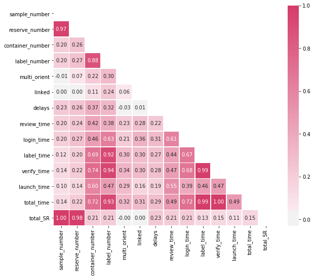

```python
# Compute the correlation matrix
df_corr = df.corr()

# Generate a mask for the upper triangle
mask = np.zeros_like(df_corr, dtype=np.bool)
mask[np.triu_indices_from(mask)] = True

# Set up the matplotlib figure
f, ax = plt.subplots(figsize=(10, 8))

# Generate a custom diverging colormap
cmap = sns.diverging_palette(255, 0, as_cmap=True)

# Draw the heatmap with the mask and correct aspect ratio
sns.heatmap(df_corr, mask=mask, cmap=cmap, center=0, square=True, linewidths=.5, annot=True, fmt='.2f')

plt.savefig('corr_heat_map.png')
```

## What does the correlation heatmap tell us?

- The closer to the value of 1 means the two metrics have a strong linear relationship.
- Tell us any metrics that are redundant (also known as overfitting) for modeling
  - Example: Label number and container number
- Shows us the important features to utilize as the training set for machine learning.

# What can we observe from this heatmap?

### Container count:

```
- Not necessary as label count gives us a better correlation with log-in, labeling, verifying.
- It does give us a better correlation to our launch times.
```

### Log-in time:

```
- Is moderately correlated to label count, review time, and total time.
```

### Label time:

```
- Is moderately correlated with log-in time.
- Is near perfect correlation with label count.
```

### Verify time:

```
- Is moderately correlated with log-in time.
- Near perfect correlation with label time.
```

### Launch time:

```
- Is moderately correlated with container number and review time
```

# Container Types

```python
type_count = df['container_type'].value_counts()
print(type_count)
#pd.value_counts(df['container_type']).plot.barh()
```

```
Glass Vials                       33
HDPE bottles                       7
Blister packs                      5
aerosol spray cans                 5
blister strips                     4
Plastic bottles                    4
Plastic Bottles                    3
Glass vials                        3
Epipens                            2
Glass bottles/jars                 2
HDPE Bottle                        2
Drug coated balloons               2
Unisticks                          2
Cryo Box                           2
Glass Vial                         2
HDPE Bottles                       2
Vial Boxes                         2
glass syringes                     2
Stick Packs                        2
ampoules                           1
Blister Cards                      1
HDPE bottles & vials               1
Glass Syringes                     1
Foil Pouches inside Steel Drum     1
Foil Pouches and blister packs     1
Shipping boxes of balloons         1
IV Bag                             1
Sachets                            1
Shipping boxes                     1
Syringes                           1
Blister in foil pouch              1
LDPE amplues in foil pouch         1
PET Amber Bottle                   1
MDI cannisters and pouches         1
coppertone spray bottles           1
Satorius Celsius-Pak, 30mL Bag     1
Blister Packs                      1
Foil pouches                       1
Foil Bags                          1
Glass Syringe                      1
Ampules in foil pouch              1
REPACKAGING                        1
Plastic Auto-Injectors             1
epipens                            1
rings                              1
Various Sized Glass Jars           1
Foil Pouches                       1
50 mL Hyclone bags                 1
Devices in a box and vials         1
plastic vials                      1
vials                              1
Carton                             1
packets                            1
Name: container_type, dtype: int64
```

# Prelaunch Condition Count

```
Ambient    55
5C         48
Frozen     17
Name: prel_condition, dtype: int64
```

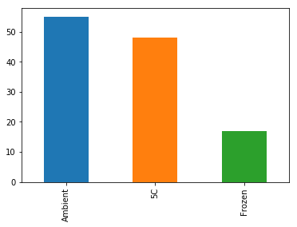

```python
prel_count = df['prel_condition'].value_counts()
pd.value_counts(df['prel_condition']).plot.bar()
print(prel_count)
```

```python
#print("Launch Owner       Count")
#launch_owner_count = df['launch_owner'].value_counts()
#pd.value_counts(df['launch_owner']).plot.bar()
```

## The biggest weakness of our model

```
          Total Time(hr) vs. Label Number
```

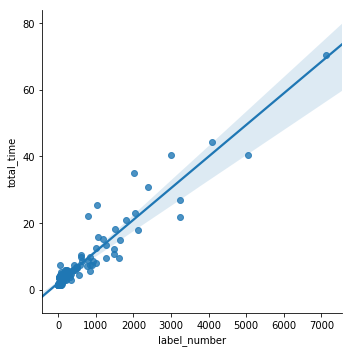

```python
launch_df = df.loc[df['label_number'] < 8000]
print('          Total Time(hr) vs. Label Number')
sns.lmplot(x='label_number',y='total_time',data = launch_df, robust=True)
plt.show()
```

## When we have outliers in the upper thousands of container

```
          Total Time(hr) vs. Label Number
```

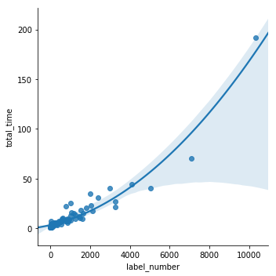

```python
print('          Total Time(hr) vs. Label Number')
sns.lmplot(x='label_number',y='total_time',data = df, order=2)
plt.show()
```

- We have a lot of data between 0 to 2000 containers.
- We do not have many data points in the upper thousands so prediction/confidence interval is very wide in that area.

```python
less_containers = df.loc[df['container_number'] < 5000]
less_containers.head()
```

|  | container_type | sample_number | reserve_number | container_number | label_number | prel_condition | multi_orient | linked | delays | review_time | login_time | label_time | verify_time | launch_time | total_time | total_SR |
| --- | --- | --- | --- | --- | --- | --- | --- | --- | --- | --- | --- | --- | --- | --- | --- | --- |
| 4 | Glass Vial | 60 | 10 | 4086 | 4086.0 | 5C | 1 | 0 | 1 | 0.25 | 1.5 | 19.0 | 22.0 | 1.50 | 44.25 | 70 |
| 5 | Blister packs | 141 | 15 | 3249 | 3249.0 | Ambient | 0 | 0 | 1 | 0.25 | 3.0 | 10.0 | 8.0 | 0.50 | 21.75 | 156 |
| 6 | Blister packs | 141 | 15 | 3249 | 3249.0 | Ambient | 0 | 0 | 0 | 0.25 | 2.0 | 11.5 | 12.5 | 0.75 | 27.00 | 156 |
| 7 | Glass Vials | 32 | 5 | 3000 | 3000.0 | Frozen | 0 | 0 | 1 | 0.25 | 1.5 | 23.0 | 15.0 | 0.75 | 40.50 | 37 |
| 8 | Unisticks | 87 | 15 | 2400 | 2400.0 | 5C | 0 | 1 | 1 | 1.00 | 4.0 | 11.0 | 14.0 | 0.75 | 30.75 | 102 |

# Visualizing the Effect of Delays

```python
#Create a dataframe just for delayed launches and not delayed launches
delay_df = df.loc[df['delays'] == 1]
nodelay_df = df.loc[df['delays'] == 0]
```

## Noticeable patterns of prelaunch condition for delays?

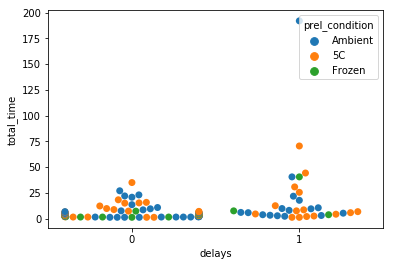

```
Delay Count
0    86
1    34
Name: delays, dtype: int64
Average delay rate: 0.2833333333333333
```

```python
sns.swarmplot(x='delays',y='total_time',hue='prel_condition', size = 7,data=df)
plt.show()

print("Delay Count")
print(str(df['delays'].value_counts()))

print("Average delay rate: " + str(df['delays'].mean()))
```

## Does our container count affect delays?

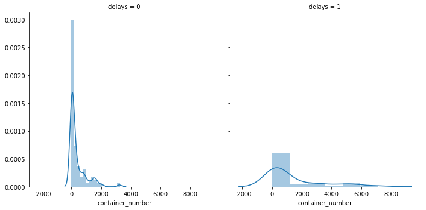

```python
container_hist = sns.FacetGrid(df, col='delays', size=5)
container_hist.map(sns.distplot,'container_number')
plt.show()
```

## Do delays affect our rate of total time?

```
          Total Time(hr) vs. Label Number
```

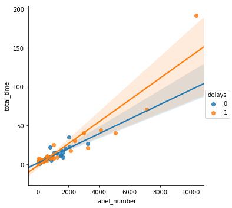

```python
print('          Total Time(hr) vs. Label Number')
sns.lmplot(x='label_number',y='total_time',hue='delays',data = df)
plt.show()
```

```
          Total Time(hr) vs. Label Number
```

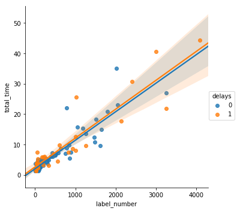

```python
print('          Total Time(hr) vs. Label Number')
sns.lmplot(x='label_number',y='total_time',hue='delays',data = less_containers)
plt.show()
```

# Delays from this data show us:

- Delays do not really affect us with small (lower thousand label) launches
- Large launches with big delays pose a huge predicatability problem due to:
  - Low sample size in the upper thousands for the model

# Does Orientation affect our rate?

```python
#Count the number of multiple orientation launches
multi_orient_count = df['multi_orient'].value_counts()
print(multi_orient_count)
```

```
0    104
1     16
Name: multi_orient, dtype: int64
```

```python
#Create dataframe for multiple orientation and non multiple orientation
multi_orient_df = df.loc[df['multi_orient'] == 1]
multi_orient_df = multi_orient_df.drop(columns=['multi_orient','total_SR','total_time'])
non_multi_orient_df = df.loc[df['multi_orient'] == 0]
non_multi_orient_df = non_multi_orient_df.drop(columns=['multi_orient','total_time','total_SR'])

multi_orient_df.head()
```

|  | container_type | sample_number | reserve_number | container_number | label_number | prel_condition | linked | delays | review_time | login_time | label_time | verify_time | launch_time |
| --- | --- | --- | --- | --- | --- | --- | --- | --- | --- | --- | --- | --- | --- |
| 0 | MDI cannisters and pouches | 70 | 17 | 5165 | 10330.0 | Ambient | 1 | 1 | 2.00 | 8.00 | 100.0 | 80.0 | 2.0 |
| 4 | Glass Vial | 60 | 10 | 4086 | 4086.0 | 5C | 0 | 1 | 0.25 | 1.50 | 19.0 | 22.0 | 1.5 |
| 12 | Glass Vials | 39 | 4 | 1507 | 2012.0 | 5C | 1 | 0 | 2.00 | 4.00 | 12.0 | 16.0 | 1.0 |
| 14 | Glass Vials | 39 | 9 | 1640 | 1640.0 | 5C | 0 | 0 | 0.25 | 0.75 | 6.0 | 7.5 | 0.5 |
| 16 | Devices in a box and vials | 8 | 5 | 930 | 1488.0 | Ambient | 0 | 0 | 0.25 | 1.00 | 4.5 | 3.0 | 2.0 |

## Multiple Orientation Heatmap

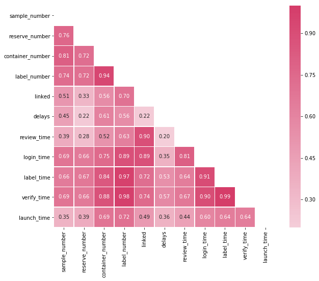

```python
# Compute the correlation matrix for multiple orientation
df_corr = multi_orient_df.corr()

# Generate a mask for the upper triangle
mask = np.zeros_like(df_corr, dtype=np.bool)
mask[np.triu_indices_from(mask)] = True

# Set up the matplotlib figure
f, ax = plt.subplots(figsize=(10, 8))

# Generate a custom diverging colormap
cmap = sns.diverging_palette(255, 0, as_cmap=True)

# Draw the heatmap with the mask and correct aspect ratio
sns.heatmap(df_corr, mask=mask, cmap=cmap, center=0, square=True, linewidths=.5, annot=True, fmt='.2f')
```

## Non multiple orientation heatmap

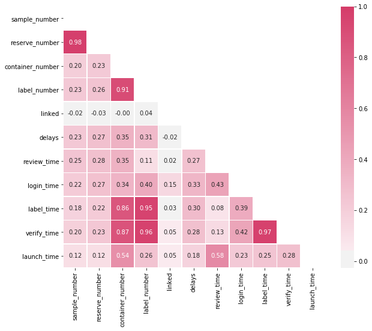

```python
# Compute the correlation matrix
df_corr = non_multi_orient_df.corr()

# Generate a mask for the upper triangle
mask = np.zeros_like(df_corr, dtype=np.bool)
mask[np.triu_indices_from(mask)] = True

# Set up the matplotlib figure
f, ax = plt.subplots(figsize=(10, 8))

# Generate a custom diverging colormap
cmap = sns.diverging_palette(255, 0, as_cmap=True)

# Draw the heatmap with the mask and correct aspect ratio
sns.heatmap(df_corr, mask=mask, cmap=cmap, center=0, square=True, linewidths=.5, annot=True, fmt='.2f')

plt.savefig('corr_heat_map.png')
```

```
Total Time(hr) vs. Label Number Multiple Orientations
```

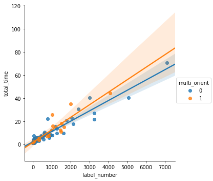

```python
print('Total Time(hr) vs. Label Number Multiple Orientations')
sns.lmplot(x='label_number',y='total_time',hue='multi_orient',data = launch_df)
plt.show()
```

### Multiple Orientations do affect rate:

- The average rate of multiple orientation falls out of the 95% confidence interval of non multiple orientation.
  - Which means there's a good chance of multiple orientations slowing us down:
    - Possible explanation: Requires more crates/set up

# Does linked samples affect log-in time?

```python
linked_count = df['linked'].value_counts()
print(linked_count)
```

```
0    110
1     10
Name: linked, dtype: int64
```

## Box Plot of Linked vs not Linked to Log-in Time

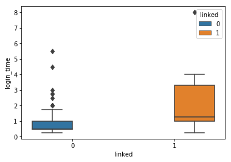

```python
sns.boxplot(x='linked',y='login_time',hue='linked', data=df, fliersize=6)
plt.show()
```

# Summary of how to estimate work hours for each launch:

- Linked Samples: If linked samples are present estimate 1 to 1.5 hours for log in time (average). Lots of outliers for unlinked sample log-in.
- Multiple Orientations: If there are multiple orientations for a launch then increase estimated/average time for labeling and verification.
- Delays: Delays can/will possibly throw off the estimation model. (slow down rate or unpredictable)

# Let's move onto the machine learning model linear regression. (Ordinary least squares)

Pros: fast, no tuning of costants, highly interpretable, well-understood math, great fit for our data

Cons: This is assuming that our data follows a linear regression.

# Starting the machine learning process

```python
#Load Scikit Learn conventionally
import sklearn as skt
```

```python
#Create separate dataframes for ambient, cold, and frozen launches

#Ambient dataframe
amb_df = df.loc[df['prel_condition'] == 'Ambient']

#Remove the outlier point from our model
amb_df = amb_df.loc[df['label_number'] < 10000]

#Cold dataframe
cld_df = df.loc[df['prel_condition'] == '5C']


#Frozen Dataframe
fzn_df = df.loc[df['prel_condition'] == 'Frozen']
```

```python
#Show first five indexes of ambient launches
amb_df.head()
```

|  | container_type | sample_number | reserve_number | container_number | label_number | prel_condition | multi_orient | linked | delays | review_time | login_time | label_time | verify_time | launch_time | total_time | total_SR |
| --- | --- | --- | --- | --- | --- | --- | --- | --- | --- | --- | --- | --- | --- | --- | --- | --- |
| 3 | packets | 108 | 16 | 5060 | 5060.0 | Ambient | 0 | 0 | 1 | 0.75 | 2.75 | 18.0 | 18.00 | 1.00 | 40.50 | 124 |
| 5 | Blister packs | 141 | 15 | 3249 | 3249.0 | Ambient | 0 | 0 | 1 | 0.25 | 3.00 | 10.0 | 8.00 | 0.50 | 21.75 | 156 |
| 6 | Blister packs | 141 | 15 | 3249 | 3249.0 | Ambient | 0 | 0 | 0 | 0.25 | 2.00 | 11.5 | 12.50 | 0.75 | 27.00 | 156 |
| 10 | Epipens | 24 | 3 | 2270 | 2130.0 | Ambient | 0 | 0 | 1 | 0.25 | 1.00 | 7.0 | 9.25 | 0.25 | 17.75 | 27 |
| 11 | Blister Packs | 56 | 12 | 2049 | 2049.0 | Ambient | 0 | 0 | 0 | 0.25 | 0.50 | 10.0 | 11.75 | 0.50 | 23.00 | 68 |

```python
#Show first five indexes of cold launches
cld_df.head()
```

|  | container_type | sample_number | reserve_number | container_number | label_number | prel_condition | multi_orient | linked | delays | review_time | login_time | label_time | verify_time | launch_time | total_time | total_SR |
| --- | --- | --- | --- | --- | --- | --- | --- | --- | --- | --- | --- | --- | --- | --- | --- | --- |
| 1 | glass syringes | 48 | 9 | 7110 | 7110.0 | 5C | 0 | 0 | 1 | 0.25 | 1.50 | 36.0 | 32.0 | 0.75 | 70.50 | 57 |
| 4 | Glass Vial | 60 | 10 | 4086 | 4086.0 | 5C | 1 | 0 | 1 | 0.25 | 1.50 | 19.0 | 22.0 | 1.50 | 44.25 | 70 |
| 8 | Unisticks | 87 | 15 | 2400 | 2400.0 | 5C | 0 | 1 | 1 | 1.00 | 4.00 | 11.0 | 14.0 | 0.75 | 30.75 | 102 |
| 12 | Glass Vials | 39 | 4 | 1507 | 2012.0 | 5C | 1 | 1 | 0 | 2.00 | 4.00 | 12.0 | 16.0 | 1.00 | 35.00 | 43 |
| 14 | Glass Vials | 39 | 9 | 1640 | 1640.0 | 5C | 1 | 0 | 0 | 0.25 | 0.75 | 6.0 | 7.5 | 0.50 | 15.00 | 48 |

```python
#Show first five indexes of frozen launches
fzn_df.head()
```

|  | container_type | sample_number | reserve_number | container_number | label_number | prel_condition | multi_orient | linked | delays | review_time | login_time | label_time | verify_time | launch_time | total_time | total_SR |
| --- | --- | --- | --- | --- | --- | --- | --- | --- | --- | --- | --- | --- | --- | --- | --- | --- |
| 7 | Glass Vials | 32 | 5 | 3000 | 3000.0 | Frozen | 0 | 0 | 1 | 0.25 | 1.50 | 23.00 | 15.0 | 0.75 | 40.50 | 37 |
| 43 | Glass Vials | 16 | 4 | 426 | 426.0 | Frozen | 0 | 0 | 0 | 0.75 | 2.75 | 1.50 | 2.0 | 0.25 | 7.25 | 20 |
| 67 | Glass Vials | 14 | 2 | 134 | 134.0 | Frozen | 0 | 0 | 0 | 0.25 | 0.50 | 0.50 | 1.0 | 0.25 | 2.50 | 16 |
| 68 | Glass Vials | 13 | 1 | 124 | 124.0 | Frozen | 0 | 0 | 0 | 0.50 | 0.75 | 1.50 | 2.0 | 0.25 | 5.00 | 14 |
| 90 | Plastic bottles | 17 | 3 | 60 | 60.0 | Frozen | 0 | 0 | 0 | 0.25 | 0.75 | 0.75 | 1.5 | 0.75 | 4.00 | 20 |

# Picking the correct features

[figure not shown]

## Summary of the data so far:

- The number of labels goes great with a linear model in predicting label time and verify time. It does decent with log-in time.
- Label count in the 5000 to 10000+ range might not go well with the linear model
- Delays do affect the variability in our launch time and slows us down.

# Creating dataframes for ambient, cold, and frozen launches

```python
#Create feature and labels for ambient
feature_cols = ['label_number']
label_time_cols = ['label_time']
verify_time_cols = ['verify_time']

amb_labels = amb_df[label_time_cols]
amb_labels_verify = amb_df[verify_time_cols]
amb_features = amb_df[feature_cols]
amb_features.head()

print(type(amb_features))
print(amb_features.shape)
amb_features.head()
```

```
<class 'pandas.core.frame.DataFrame'>
(54, 1)
```

|  | label_number |
| --- | --- |
| 3 | 5060.0 |
| 5 | 3249.0 |
| 6 | 3249.0 |
| 10 | 2130.0 |
| 11 | 2049.0 |

```python
#Create feature and labels for cold
cld_features = cld_df[feature_cols]
cld_labels = cld_df[label_time_cols]
cld_labels_verify = cld_df[verify_time_cols]
cld_features.head()
```

|  | label_number |
| --- | --- |
| 1 | 7110.0 |
| 4 | 4086.0 |
| 8 | 2400.0 |
| 12 | 2012.0 |
| 14 | 1640.0 |

```python
#Create feature and labels for frozen
fzn_features = fzn_df[feature_cols]
fzn_labels = fzn_df[label_time_cols]
fzn_labels_verify = fzn_df[verify_time_cols]
fzn_features.head()
```

|  | label_number |
| --- | --- |
| 7 | 3000.0 |
| 43 | 426.0 |
| 67 | 134.0 |
| 68 | 124.0 |
| 90 | 60.0 |

# Splitting our data into testing and training sets (Labeling)

```python
#Import module to split data into testing and training set
from sklearn.model_selection import train_test_split

#Run module to break into training and testing sets for labeling and verifying calculations

#X_train, X_test, y_train, y_testn = train_test_split(features,labels)


#Ambient Labeling Time Set
amb_train, amb_test, amb_y_train, amb_y_test = train_test_split(amb_features, amb_labels)
#Ambient Verifying Time Set
amb_train_verify, amb_test_verify, amb_verify_train, amb_verify_test = train_test_split(amb_features, amb_labels_verify)

#Cold Labeling Time Set
cld_train, cld_test, cld_y_train, cld_y_test = train_test_split(cld_features, cld_labels)
#Cold Verifying Time Set
cld_train_verify, cld_test_verify, cld_verify_train, cld_verify_test = train_test_split(cld_features, cld_labels_verify)

#Frozen Labeling Time Set
fzn_train, fzn_test, fzn_y_train, fzn_y_test = train_test_split(fzn_features, fzn_labels)
#Frozen Verifying Time Set
fzn_train_verify, fzn_test_verify, fzn_verify_train, fzn_verify_test = train_test_split(fzn_features, fzn_labels_verify)
```

# Linear regression with sci-kit learn (Labeling)

```python
#import scikit learn linear regression conventionally
from sklearn.linear_model import LinearRegression

#Instantiate linear objects for each prelaunch condition.
amb_label_time_reg = LinearRegression(fit_intercept=False)
cld_label_time_reg = LinearRegression(fit_intercept=False)
fzn_label_time_reg = LinearRegression(fit_intercept=False)

#Fit the model to our ambient training set
amb_label_time_reg.fit(amb_train, amb_y_train)
cld_label_time_reg.fit(cld_train, cld_y_train)
fzn_label_time_reg.fit(fzn_train, fzn_y_train)
```

```
LinearRegression(copy_X=True, fit_intercept=False, n_jobs=1, normalize=False)
```

```python
#Print the coefficient/slope
amb_label_rate = float(amb_label_time_reg.coef_)
cld_label_rate = float(cld_label_time_reg.coef_)
fzn_label_rate = float(fzn_label_time_reg.coef_)

print('Ambient Label rate hours per container:')
print(amb_label_rate)

print('Cold Label rate hours per container:')
print(cld_label_rate)

print('Frozen Label rate hours per container:')
print(fzn_label_rate)
```

```
Ambient Label rate hours per container:
0.003414473122325026
Cold Label rate hours per container:
0.004952872035128337
Frozen Label rate hours per container:
0.004085999048016863
```

```python
#Convert to seconds per container

amb_label_sec = float(amb_label_time_reg.coef_) * 60 ** 2
print('Ambient launches take on average ' + str(amb_label_sec) + ' seconds to label a container')


cld_label_sec = float(cld_label_time_reg.coef_) * 60 ** 2
print('Cold launches take on average ' + str(cld_label_sec) + ' seconds to label a container')


fzn_label_sec = float(fzn_label_time_reg.coef_) * 60 ** 2
print('Frozen launches take on average ' + str(fzn_label_sec) + ' seconds to label a container')
```

```
Ambient launches take on average 12.292103240370093 seconds to label a container
Cold launches take on average 17.830339326462013 seconds to label a container
Frozen launches take on average 14.709596572860706 seconds to label a container
```

# Now we test the training set to the test set for labeling

```python
print('% Accuracy for labeling time')
amb_r_sq_label = amb_label_time_reg.score(amb_test, amb_y_test)
cld_r_sq_label = cld_label_time_reg.score(cld_test, cld_y_test)
fzn_r_sq_label = fzn_label_time_reg.score(fzn_test, fzn_y_test)
print(amb_r_sq_label)
print(cld_r_sq_label)
print(fzn_r_sq_label)
```

```
% Accuracy for labeling time
0.9502586584905155
0.6042280302471583
0.7057912424599637
```

# Verify Time Linear Regression

```python
#Instantiate linear objects for each prelaunch condition for verification.
amb_verify_time_reg = LinearRegression(fit_intercept=False)
cld_verify_time_reg = LinearRegression(fit_intercept=False)
fzn_verify_time_reg = LinearRegression(fit_intercept=False)

#Fit the model to our ambient training set
amb_verify_time_reg.fit(amb_train_verify, amb_verify_train)
cld_verify_time_reg.fit(cld_train_verify, cld_verify_train)
fzn_verify_time_reg.fit(fzn_train_verify, fzn_verify_train)
```

```
LinearRegression(copy_X=True, fit_intercept=False, n_jobs=1, normalize=False)
```

```python
#Print the coefficient/slope for each prelaunch condition
amb_verify_rate = float(amb_verify_time_reg.coef_)
cld_verify_rate = float(cld_verify_time_reg.coef_)
fzn_verify_rate = float(fzn_verify_time_reg.coef_)
print('Ambient verify rate hours per container:')
print(amb_verify_rate)

print('Cold verify rate hours per container:')
print(cld_verify_rate)

print('Frozen verify rate hours per container:')
print(fzn_verify_rate)
```

```
Ambient verify rate hours per container:
0.003607134072275453
Cold verify rate hours per container:
0.005042386862659208
Frozen verify rate hours per container:
0.006346237125598797
```

```python
#Convert to seconds per container

amb_verify_sec = float(amb_verify_time_reg.coef_) * 60 ** 2
print('Ambient launches take on average ' + str(amb_verify_sec) + ' seconds to verify a container')


cld_verify_sec = float(cld_verify_time_reg.coef_) * 60 ** 2
print('Cold launches take on average ' + str(cld_verify_sec) + ' seconds to verify a container')


fzn_verify_sec = float(fzn_verify_time_reg.coef_) * 60 ** 2
print('Frozen launches take on average ' + str(fzn_verify_sec) + ' seconds to verify a container')
```

```
Ambient launches take on average 12.985682660191632 seconds to verify a container
Cold launches take on average 18.15259270557315 seconds to verify a container
Frozen launches take on average 22.84645365215567 seconds to verify a container
```

# Now we test our training set with test set

```python
print('Ambient verification accuracy:')
#print(amb_r_sq_label)
amb_r_sq_verify = amb_verify_time_reg.score(amb_test, amb_y_test)
print(amb_r_sq_verify)

print('\nCold verification accuracy:')
cld_r_sq_verify = cld_verify_time_reg.score(cld_test, cld_y_test)
print(cld_r_sq_verify)

print('\nFrozen verification accuracy:')
fzn_r_sq_verify = fzn_verify_time_reg.score(fzn_test, fzn_y_test)
print(fzn_r_sq_verify)
```

```
Ambient verification accuracy:
0.9563133683883059

Cold verification accuracy:
0.5712206717186015

Frozen verification accuracy:
0.9586252344572144
```

# Descriptive Stats Calculations (labeling)

```python
#Standard Deviation of label time for each prelaunch condition
amb_stddev_label_time = amb_df['label_time'].std()
cld_stddev_label_time = cld_df['label_time'].std()
fzn_stddev_label_time = fzn_df['label_time'].std()
print('Standard Dev of Label Count')
print(amb_stddev_label_time)
print(cld_stddev_label_time)
print(fzn_stddev_label_time)

#Standard deviation of container count for each prelaunch condition
amb_stddev_label_number = amb_df['label_number'].std()
cld_stddev_label_number = cld_df['label_number'].std()
fzn_stddev_label_number = fzn_df['label_number'].std()
print('\nStandard Dev of Label Count')
print(amb_stddev_label_number)
print(cld_stddev_label_number)
print(fzn_stddev_label_number)

#Average of container count for each prelaunch condition
amb_avg_label_number = amb_df['label_number'].mean()
cld_avg_label_number = cld_df['label_number'].mean()
fzn_avg_label_number = fzn_df['label_number'].mean()
print('\nAverage label number')
print(amb_avg_label_number)
print(cld_avg_label_number)
print(fzn_avg_label_number)

#R square values for each prelaunch condition
print('\nR square values')
print(amb_r_sq_label)
print(cld_r_sq_label)
print(fzn_r_sq_label)

#Count the number of launches for each prelaunch condition
amb_samp_size = amb_df['label_number'].count()
cld_samp_size = cld_df['label_number'].count()
fzn_samp_size = fzn_df['label_number'].count()
print('\nCounts')
print('ambient count: ' + str(amb_samp_size))
print('cold count: ' + str(cld_samp_size))
print('frozen count: ' + str(fzn_samp_size))

#Calculate the standard error of the estimate for each prelaunch condition.
amb_std_err_est_label = amb_stddev_label_time * ((1 - amb_r_sq_label) ** (1/2)) * ((amb_samp_size)/(amb_samp_size - 2)) ** (1/2)
cld_std_err_est_label = cld_stddev_label_time * ((1 - cld_r_sq_label) ** (1/2)) * ((cld_samp_size)/(cld_samp_size - 2)) ** (1/2)
fzn_std_err_est_label = amb_stddev_label_time * ((1 - fzn_r_sq_label) ** (1/2)) * ((fzn_samp_size)/(fzn_samp_size - 2)) ** (1/2)

print(amb_std_err_est_label)
print(cld_std_err_est_label)
print(fzn_std_err_est_label)
```

```
Standard Dev of Label Count
3.4893424891072704
6.017812562782272
5.441829750131086

Standard Dev of Label Count
988.612215789158
1214.1360403464207
719.219552505271

Average label number
614.3333333333334
722.875
236.47058823529412

R square values
0.9502586584905155
0.6042280302471583
0.7057912424599637

Counts
ambient count: 54
cold count: 48
frozen count: 17
0.7930444933060858
3.8672555879056483
2.0148848340088343
```

```python
amb_df.mean()
```

```
sample_number        28.592593
reserve_number        4.203704
container_number    684.833333
label_number        614.333333
multi_orient          0.055556
linked                0.092593
delays                0.277778
review_time           0.402778
login_time            0.967593
label_time            2.402778
verify_time           2.777778
launch_time           0.495370
total_time            7.046296
total_SR             32.796296
dtype: float64
```

```python
#Standard Deviation of verify time for each prelaunch condition
amb_stddev_verify_time = amb_df['verify_time'].std()
cld_stddev_verify_time = cld_df['verify_time'].std()
fzn_stddev_verify_time = fzn_df['verify_time'].std()
print('Standard Dev of Label Count')
print(amb_stddev_verify_time)
print(cld_stddev_verify_time)
print(fzn_stddev_verify_time)

#R square values for each prelaunch condition
print('\nR square values')
print(amb_r_sq_verify)
print(cld_r_sq_verify)
print(fzn_r_sq_verify)

#Calculate the standard error of the estimate for each prelaunch condition.
amb_std_err_est_verify = amb_stddev_verify_time * ((1 - amb_r_sq_verify) ** (1/2)) * ((amb_samp_size)/(amb_samp_size - 2)) ** (1/2)
cld_std_err_est_verify = cld_stddev_verify_time * ((1 - cld_r_sq_verify) ** (1/2)) * ((cld_samp_size)/(cld_samp_size - 2)) ** (1/2)
fzn_std_err_est_verify = amb_stddev_verify_time * ((1 - fzn_r_sq_verify) ** (1/2)) * ((fzn_samp_size)/(fzn_samp_size - 2)) ** (1/2)
```

```
Standard Dev of Label Count
3.690779774778217
6.1397636513985985
3.502165821484825

R square values
0.9563133683883059
0.5712206717186015
0.9586252344572144
```

# Once we trained our model we can use Python to create the excel tool

```python
#Import Excel Interaction Package
import openpyxl
from openpyxl import Workbook
wb = Workbook()
wb.create_sheet("Input Tables")
wb.title = 'Prediction_Table'

#Load Prediction_Table and create the sheets
#wb = openpyxl.load_workbook('Prediction_Table.xlsx')

#Create the input tables sheet
sheet = wb['Input Tables']
```

```python
#Fill in column and row names
sheet['A1'] = 'Variables'
sheet['A2'] = 'Number of Labels'
sheet['A4'] = 'Desired Prediction Level'
sheet['A5'] = 'Alpha'
sheet['A14'] = 'Label (hours/label count)'
sheet['A15'] = 'Verify (hours/label count)'
sheet['A16'] = 'Average label count'
sheet['A17'] = 'Standard dev. label count'
sheet['A18'] = 'Sample size'
sheet['A19'] = 'Std_err_estimate labeling'
sheet['A20'] = 'Std_err_estimate verifying'
sheet['B1'] = 'Enter Below'


#Fill in label rate to the spreadsheet
sheet['B13'] = 'Ambient'
sheet['C13'] = 'Cold'
sheet['D13'] = 'Frozen'
sheet['B14'] = amb_label_rate
sheet['C14'] = cld_label_rate
sheet['D14'] = fzn_label_rate

#Fill in the verify rate to the spreadsheet
sheet['B15'] = amb_verify_rate
sheet['C15'] = cld_verify_rate
sheet['D15'] = fzn_verify_rate

#Fill in the standard error of estimate of labeling for each prelaunch condition
sheet['B19'] = amb_std_err_est_label
sheet['C19'] = cld_std_err_est_label
sheet['D19'] = fzn_std_err_est_label

#Fill in the standard error of estimate of verifying for each prelaunch condition
sheet['B20'] = amb_std_err_est_verify
sheet['C20'] = cld_std_err_est_verify
sheet['D20'] = fzn_std_err_est_verify

#Fill in the average label count for each prelaunch condition
sheet['B16'] = amb_df['label_number'].mean()
sheet['C16'] = cld_df['label_number'].mean()
sheet['D16'] = fzn_df['label_number'].mean()

#Fill in standard dev. label count for each prelaunch condition
sheet['B17'] = amb_df['label_number'].std()
sheet['C17'] = cld_df['label_number'].std()
sheet['D17'] = fzn_df['label_number'].std()

#Fill in sample size for each prelaunch condition
sheet['B18'] = amb_df['label_number'].count()
sheet['C18'] = cld_df['label_number'].count()
sheet['D18'] = fzn_df['label_number'].count()

#Fill Desired Prediction Level
sheet['B4'] = .9
sheet['B5'] = '=1 - B4'


#Prediction Table Ambient
#Fill in column names for ambient prelaunch condition labeling time
sheet['J9'] = 'Pred for prelaunch ambient'
sheet['J10'] = 'Average label time prediction'
sheet['K10'] = 't-value'
sheet['L10'] = 'St. Error of Pred.(hrs)'
sheet['M10'] = 'Margin of Error(hrs)'
sheet['N10'] = 'Lower Bound (hrs)'
sheet['O10'] = 'Upper Bound (hrs)'
sheet['P10'] = 'Interval Width'

#Fill values for labeling time ambient
sheet['J11'] = '=B14 * B2'
sheet['K11'] = '=TINV(B5,B18-1)'
sheet['L11'] = '=B19 * SQRT((1) + (1/B18) + ((B2 - B16)^2/(B17 * (B18-1))))'
sheet['M11'] = '=L11 * K11'
sheet['N11'] = '=IF(J11 - M11<0, 0, J11-M11)'
sheet['O11'] = '=J11 + M11'
sheet['P11'] = '=O11 - N11'

#Prediction Table Cold
#Fill in column names for ambient prelaunch condition labeling time
sheet['J15'] = 'Pred for prelaunch Cold'
sheet['J16'] = 'Average label time prediction'
sheet['K16'] = 't-value'
sheet['L16'] = 'St. Error of Pred.(hrs)'
sheet['M16'] = 'Margin of Error(hrs)'
sheet['N16'] = 'Lower Bound (hrs)'
sheet['O16'] = 'Upper Bound (hrs)'
sheet['P16'] = 'Interval Width'

#Fill values for labeling time ambient
sheet['J17'] = '=C14 * B2'
sheet['K17'] = '=TINV(B5,C18-1)'
sheet['L17'] = '=C19 * SQRT((1) + (1/C18) + ((B2 - C16)^2/(C17 * (C18-1))))'
sheet['M17'] = '=L17 * K17'
sheet['N17'] = '=IF(J17 - M17<0, 0, J17-M17)'
sheet['O17'] = '=J17 + M17'
sheet['P17'] = '=O17 - N17'

wb.save('Prediction_Table.xlsx')
```

# Stability Launch Time Heat Map (Draft)

[figure not shown]